# Original Code for Homework #2

Laura Brubaker-Wittman

9/24/2019

## Problem:

Every Saturday, at the same time, a primatologist goes and sits in the forest in the morning and listens for titi monkey calls, counting the number of calls they hear in a 2-hour window from 5am to 7am. Based on previous knowledge, she believes that the mean number calls she will hear in that time is exactly 15. Let *X* represent the appropriate Poisson random variable of the number of calls heard in each monitoring session.

**Questions:**

1. *What is the probability that she will hear more than 8 calls during any given session?*

   For this one, I will use the ppois() function, since we want to know the cumulative probability of 9 - 15 calls.

```r
x <- 9:15 # The specific interval we are looking for probabilities for
l <- 15 # How many we expect in an hour
ppois(q = x, l)
```

```
## [1] 0.06985366 0.11846441 0.18475180 0.26761103 0.36321784 0.46565371
## [7] 0.56808958
```

2. *What is the probability that she will hear no calls in a session?*

   Not sure how this one will work? But let’s try using the same formula:

```r
x <- 0
l <- 15
ppois(q = 0, l)
```

```
## [1] 3.059023e-07
```

*Yikes!* So basically a **very** small chance of hearing 0 . That makes sense!

3. *What is the probability that she will hear exactly 3 calls in a session?*

   Well, it seemed to work with setting it for just O in the last question, let’s see what happens when we set x at 3 and not a range like in question 1.

```r
x <- 3
l <- 15
ppois(q = x, l)
```

```
## [1] 0.0002113785
```

Ok, still a *really* small number. While if the average is 15 and 3 is way below that, so a small probability for exactly 3 makes sense, I am not sure if this is how we sent up the function for this type of question.

4. *Plot the relevant Poisson mass function over the values in range 0 ≤ x ≤ 30.*

   Ok, here is where it starts getting tricky! Let’s see what we can do:

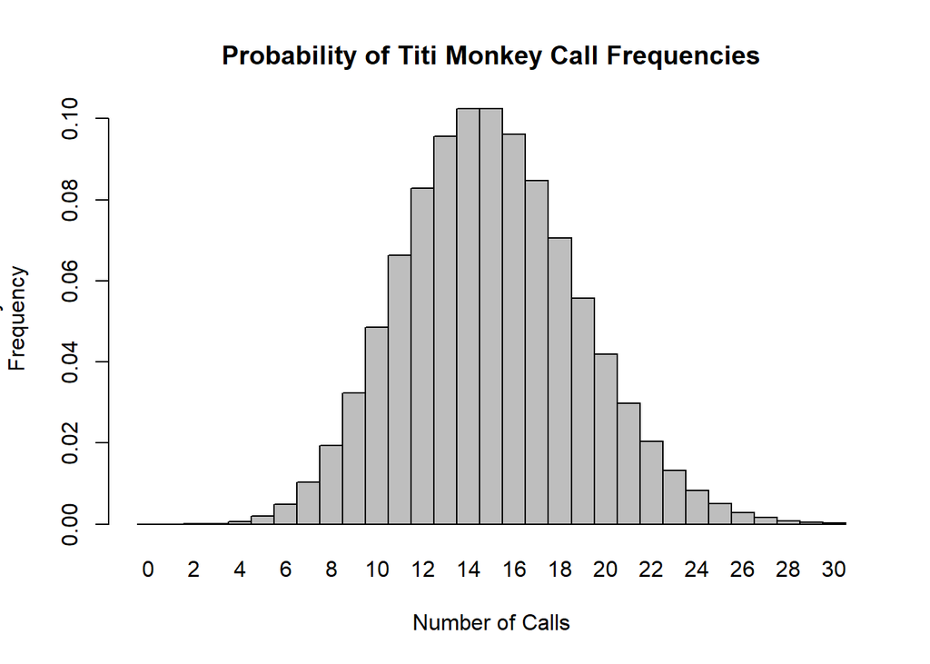

```r
x <- 0:30
l <- 15
barplot(dpois(x=x,l),names.arg=x,space=0,xlab="Number of Calls",ylab="Probability of Call
Frequency",main="Probability of Titi Monkey Call Frequencies")
```

WHAT?! Look at that! It kind of makes sense too, that the distribution for highest call frequency probability would be around 15, which is the average, and then taper off towards either end. I hope this is correct… or at least some version of correct!

5. *Simulate 104 results from this distribution (i.e., 2 years of Saturday monitoring sessions).*

   Ok, from class, I believe this is where we need to do some **bootstrapping**!

   From googling and using the **Help** section in *R Studio*, I think we can use the function rpois() to do a simulation. It might not be right, but let’s give it a shot!

```r
x <- 104 # number of random values we want to return
l <- 15 # average of titi calls heard during a session, AKA our lamda for this problem
rpois(x,l)
```

```
##   [1] 25 20 12 16 19 17  6 10  8 12 10 16 14  9 14 21 11 17 10 15 14 19  6
##  [24] 19 13 14 15 16 16 14 19 15 15 13 14  9 19 10 18 19 15 14 12  9 20 20
##  [47] 15 14 24 15 23 13 19 14 21 16 12 14 18 15 10 13 18  9 20 15 16 20 18
##  [70] 19  8 18 15 11 16 10 19 12 23 11 17 16 12 14 23 11 11 15 21 10 15 13
##  [93]  5 16  9 14 10 15 24 18 11 17 16 21
```

Ok, so this is the random set of numbers it built based on that infomration! Makes sense, and it would be different every time.

6. *Plot the simulated results using hist() and use xlim() to set the horizontal limits to be from 0 to 30. How does your histogram compare to the shape of the probability mass function you plotted above?*

This took awhile to figure out and had to play with several components, looking up references from the modules, online, and the **Help** section in *R Studio*. Here is the code and output:

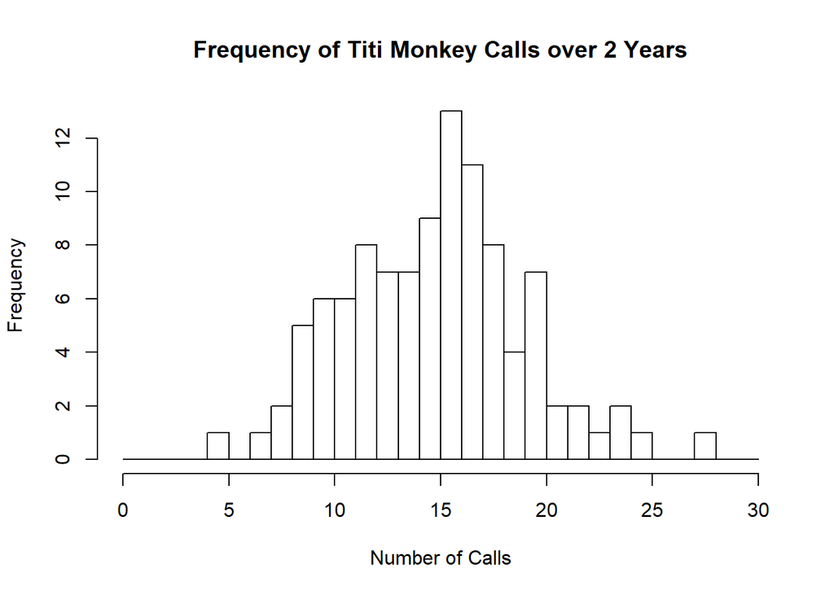

```r
hist(x = (rpois(x,l)),
     breaks = 0:30,
     main = "Frequency of Titi Monkey Calls over 2 Years",
     xlab = "Number of Calls",
     xlim = c(0,30)
)
```

This distribution makes sense, even though we have very few to no results for the numbers at either end of the x-axis. It looks similar to the one created above, and it would probably look more and more like it over time with more and more sessions.

## 5 Challenges:

1. I had to teach myself a lot of the statistics and knowing which each of the component of the Poisson Distribution formula meant. Once I watched a couple videos on YouTube, it started to make more sense!
2. Still not completely comfortable about the differences between dpois and ppois, though the cumulative aspect of ppois makes sense.
3. Figuring out all the components of the barplots and histograms and how they need to be set up! The **Help** section in *R Studio* did provide a lot of guidance in this, but I still feel like I am just patching everything together each time. Hoping it will become more second nature with practice.
4. Not sure if the answers for #2 and #3 are correct? Very small probabilities make sense, but want to know if I am setting up the functions correctly.
5. Just feeling really rusty with stats in general and feeling a bit overwhelmed with all the more advanced topics as I have not done even basic stats for awhile! But again, this will just take time and practice.